# Import des packages

```python
import pandas as pd                     # pour la lecture et la manipulation des données
import numpy as np                      # pour les opérations mathématiques/algébre linéaire
import matplotlib.pyplot as plt         # pour le tracer de graphes
import seaborn as sns                   # pour le tracer de graphes
import sklearn                          # pour l'ACP
```

# Lecture du fichier Petrole.dat et affichage des premières lignes

```python
Data = pd.read_csv("Petrole.dat", sep='\t', header=0, index_col=0)
Data.head()
```

|  | NET | INT | SUB | LMT | DCT | IMM | EXP | VRD |
| --- | --- | --- | --- | --- | --- | --- | --- | --- |
| 1969 | 35.86 | 7.92 | 1.76 | 14.76 | 39.70 | 50.90 | 10.68 | 38.42 |
| 1970 | 32.42 | 7.86 | 1.88 | 19.64 | 38.20 | 53.18 | 10.02 | 36.80 |
| 1971 | 36.02 | 7.12 | 3.82 | 18.86 | 34.18 | 53.88 | 10.80 | 35.32 |
| 1972 | 34.78 | 6.66 | 3.46 | 19.44 | 35.66 | 54.10 | 10.16 | 35.74 |
| 1973 | 32.02 | 6.20 | 4.28 | 18.78 | 38.72 | 49.90 | 12.38 | 37.72 |

— NET : Situation nette ; ensemble des capitaux propres de l’entreprise.

— INT : Intérets ; ensemble des frais financiers support´es par l’entreprise.

— SUB : Subventions ; montant total des aides accord´ees par l’Etat.

— LMT : Dettes à moyen et long terme.

— DCT : Dettes à court terme.

— IMM : Immobilisations ; ensemble des terrains et du mat´eriel de l’entreprise.

— EXP : Valeurs d’exploitation ; ensemble des stocks de mati`eres et produits relatifs à l’exploitation de l’entreprise.

— VRD : Valeurs réalisables et disponibles ; ensemble des cr´eances `a court terme de l’entreprise

# Question 1 : Correlations

```
          NET       INT       SUB       LMT       DCT       IMM       EXP  \
NET  1.000000  0.725867 -0.472294 -0.241111 -0.890002  0.576720 -0.691839
INT  0.725867  1.000000 -0.449435 -0.460013 -0.516256  0.205202 -0.339781
SUB -0.472294 -0.449435  1.000000 -0.409285  0.539677 -0.640594  0.607878
LMT -0.241111 -0.460013 -0.409285  1.000000 -0.190687  0.583718 -0.390388
DCT -0.890002 -0.516256  0.539677 -0.190687  1.000000 -0.836384  0.866171
IMM  0.576720  0.205202 -0.640594  0.583718 -0.836384  1.000000 -0.955045
EXP -0.691839 -0.339781  0.607878 -0.390388  0.866171 -0.955045  1.000000
VRD  0.629260  0.524575 -0.183203 -0.358242 -0.472050  0.305631 -0.574166

          VRD
NET  0.629260
INT  0.524575
SUB -0.183203
LMT -0.358242
DCT -0.472050
IMM  0.305631
EXP -0.574166
VRD  1.000000
```

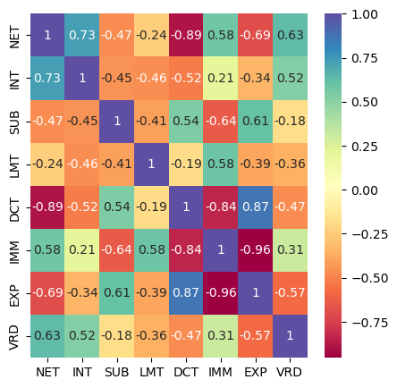

```python
print(Data.corr())

fig, axes = plt.subplots(figsize=(5,5))
sns.heatmap(Data.corr(), annot=True, cmap='Spectral')
```

CP1 et CP2 expliquent ensemble environ 82.80% de la variance totale des données, capturant la majorité de l'information des variables initiales.

Situation nette (NET) a une forte corrélation positive avec les intérêts (INT) et une forte corrélation négative avec les dettes à court terme (DCT).

Immobilisations (IMM) montrent une corrélation négative avec les valeurs d'exploitation (EXP), suggérant une gestion inefficace des actifs immobilisés

# Question 2 : Standardization des variables

```python
from sklearn.preprocessing import StandardScaler
sc = StandardScaler()
StandardizedData = sc.fit_transform(Data)
```

# Question 3 : valeur propres

```
Valeurs propres:
[4.84484002e+00 2.22085501e+00 7.81968011e-01 4.63811705e-01
 1.52443775e-01 6.94148143e-02 5.64931050e-32 4.67174537e-32]
Pourcentage cumulé de variance expliquée:
[0.56775469 0.82801114 0.91964801 0.97400095 0.99186545 1.
 1.         1.        ]
```

```
<BarContainer object of 8 artists>
```

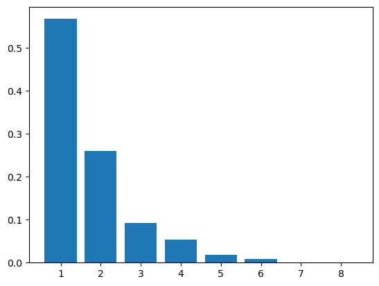

```python
from sklearn.decomposition import PCA
pca = PCA()
pca.fit(StandardizedData)
AxesPrincipaux = pca.components_.transpose()
ComposantesPrincipales = pca.fit_transform(StandardizedData)

print("Valeurs propres:")
print(pca.explained_variance_)
print("Pourcentage cumulé de variance expliquée:")
print(np.cumsum(pca.explained_variance_ratio_))
fig, axes = plt.subplots()
plt.bar(range(1,pca.n_components_+1),pca.explained_variance_ratio_)

#print(np.sum(Data.loc[:,'NET':'DCT'],axis = 1))
#print(np.sum(Data.loc[:,'IMM':'VRD'],axis = 1))
```

# Question 4 : Cercle des corrélations

```
[1. 1. 1. 1. 1. 1. 1. 1.]
```

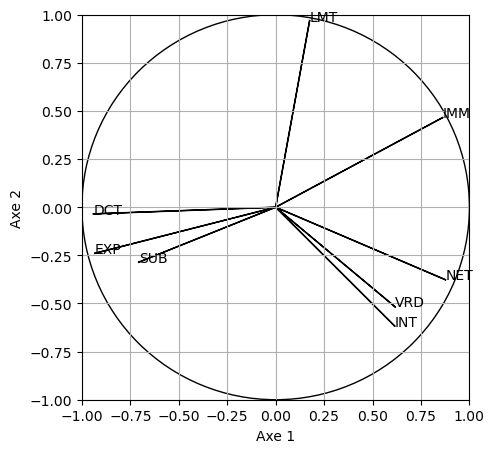

```python
axe1 = 0
axe2 = 1

# Calcul des corrélations entre les variables de départs et les composantes principales
corvar = np.zeros((pca.n_components_,pca.n_components_))

for i in range(pca.n_components_):
    corvar[:,i] = np.sqrt(pca.explained_variance_[i] * (pca.n_samples_-1)/pca.n_samples_) * AxesPrincipaux[:,i]

# vérification du calcul\n",
print(np.sum(corvar**2, axis = 1))

# Tracer du cercle des correlations
fig, axes = plt.subplots(figsize=(5,5))
axes.set_xlim(-1,1)
axes.set_ylim(-1,1)
axes.add_patch(plt.Circle((0,0),1,fill=False))
plt.grid()
plt.xlabel('Axe ' + str(axe1 + 1))
plt.ylabel('Axe ' + str(axe2 + 1))

for i in range(pca.n_components_):
    plt.arrow(0, 0, corvar[i,axe1], corvar[i,axe2])
    plt.annotate(Data.columns[i], (corvar[i,axe1],corvar[i,axe2]))
```

# Question 5 :

## Représentation des individus sur les plans principaux

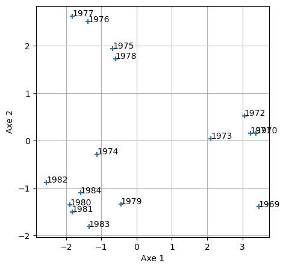

```python
axe1 = 0
axe2 = 1

fig, axes = plt.subplots(figsize=(5,5))
plt.scatter(ComposantesPrincipales[:,axe1],ComposantesPrincipales[:,axe2], marker='+')
plt.grid()
plt.xlabel('Axe ' + str(axe1 + 1))
plt.ylabel('Axe ' + str(axe2 + 1))
for i in range(pca.n_samples_):
    plt.annotate(Data.index[i], (ComposantesPrincipales[i,axe1],ComposantesPrincipales[i,axe2]))
```

Les observations les plus éloignées du centre du graphique de l'ACP sont les plus influentes dans la définition des composantes principales.

## Contribution des individus aux axes

```
             0
1969  2.470449
1970  2.361911
1971  2.138961
1972  1.922577
1982  1.340797
1973  0.913260
1980  0.733859
1981  0.688068
1977  0.680086
1984  0.519247
1976  0.388309
1983  0.375709
1974  0.258395
1975  0.093883
1978  0.074106
1979  0.040385
```

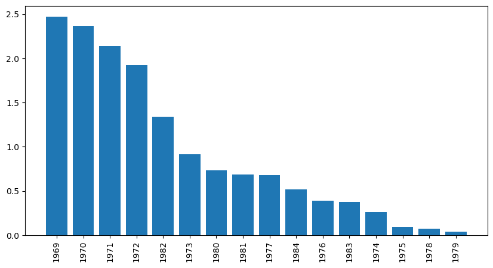

```python
Axe = 0

Contribution = ComposantesPrincipales**2
for i in range(pca.n_components_):
    #Contribution[:,i] = Contribution[:,i]/(pca.n_samples_*pca.explained_variance_[i])
    Contribution[:,i] = Contribution[:,i]/pca.explained_variance_[i]

Contribution = pd.DataFrame(Contribution, index= Data.index)
SortedContribution=Contribution.sort_values(by=[Axe], ascending=False)
print(pd.DataFrame(SortedContribution[Axe], index=SortedContribution.index))


fig, axes = plt.subplots(figsize=(10,5))
plt.bar(range(pca.n_samples_),SortedContribution[Axe], tick_label = SortedContribution.index)
plt.tick_params(axis='x', rotation=90)
```

Les observations les plus éloignées du centre du graphique de l'ACP sont les plus influentes dans la définition des composantes principales.

# Question 6 : Qualité de représentation des individus

```
             0
1972  0.922757
1970  0.919886
1971  0.894720
1982  0.858636
1969  0.789629
1973  0.774181
1981  0.501432
1974  0.465015
1984  0.398858
1980  0.379372
1977  0.319761
1983  0.217761
1976  0.210670
1978  0.090751
1975  0.081389
1979  0.059506
```

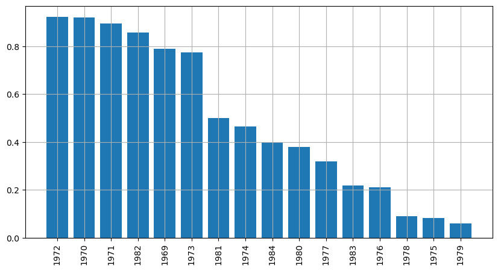

```python
axe = [0]

d2=np.sum(ComposantesPrincipales**2,axis=1)

Cos2 = ComposantesPrincipales**2
for i in range(pca.n_components_):
    Cos2[:,i] = Cos2[:,i]/d2

Cos2 = pd.DataFrame(np.sum(Cos2[:, axe], axis = 1), index= Data.index)
SortedCos2=Cos2.sort_values(by=[0], ascending=False)
print(pd.DataFrame(SortedCos2[0], index=SortedCos2.index))

fig, axes = plt.subplots(figsize=(10,5))
plt.bar(range(pca.n_samples_),SortedCos2[0], tick_label = SortedCos2.index)
plt.tick_params(axis='x', rotation=90)
plt.grid()
```

Les individus avec des cos² élevés sont bien représentés par les composantes principales, ce qui permet une interprétation fiable de leurs positions dans l'espace des composantes principales.

# Question 7 : Relier CP1 et les variables

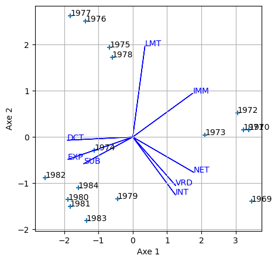

```python
axe1 = 0
axe2 = 1

# Calcul des corrélations entre les variables de départs et les composantes principales
corvar = np.zeros((pca.n_components_,pca.n_components_))

for i in range(pca.n_components_):
    corvar[:,i] = np.sqrt(pca.explained_variance_[i] * (pca.n_samples_-1)/pca.n_samples_) * AxesPrincipaux[:,i]


# Tracer des individus
fig, axes = plt.subplots(figsize=(5,5))
plt.scatter(ComposantesPrincipales[:,axe1],ComposantesPrincipales[:,axe2], marker='+')
plt.grid()
plt.xlabel('Axe 1')
plt.ylabel('Axe 2')

# Tracer du cercle des corrélations
rayon=(np.min(np.abs([plt.xlim(), plt.ylim()])))
corvar = rayon*corvar

for i in range(pca.n_samples_):
    plt.annotate(Data.index[i], (ComposantesPrincipales[i,axe1],ComposantesPrincipales[i,axe2]))

for i in range(pca.n_components_):
    plt.arrow(0, 0, corvar[i,axe1], corvar[i,axe2], color = 'blue')
    plt.annotate(Data.columns[i], (corvar[i,axe1],corvar[i,axe2]), color = 'blue')
```

# Interprétations et Recommandations

### Réduction des Dettes à Court Terme (DCT) :

- Étant donné la forte corrélation négative entre les dettes à court terme et la situation nette, l'entreprise devrait prioriser la réduction de ses dettes à court terme pour améliorer sa situation financière globale.

- Stratégies recommandées : Renégociation des termes de la dette, amélioration de la gestion des flux de trésorerie, et utilisation de financements à plus long terme.

### Optimisation des Immobilisations (IMM) :

- La corrélation négative entre les immobilisations et les valeurs d'exploitation suggère que les actifs immobilisés ne sont pas utilisés de manière optimale.

- Stratégies recommandées : Réévaluation et potentielle liquidation des actifs sous-performants, investissement dans des technologies ou équipements plus efficaces, et amélioration de la maintenance préventive.

### Amélioration de la Gestion des Intérêts (INT) :

- Une gestion efficace des coûts financiers peut améliorer la situation nette de l'entreprise.

- Stratégies recommandées : Réduction des frais financiers par la renégociation des taux d'intérêt ou la consolidation de la dette, et optimisation de l'utilisation des capitaux propres.

### Utilisation Efficace des Subventions (SUB) :

- Les subventions jouent un rôle important dans la structure financière de l'entreprise.

- Stratégies recommandées : Maximisation de l'utilisation des subventions pour des projets à forte valeur ajoutée, et exploration de nouvelles opportunités de subventions ou d'aides publiques.

### Gestion des Stocks et Créances (EXP et VRD) :

- Une gestion efficace des stocks et des créances à court terme peut libérer des liquidités et améliorer la santé financière de l'entreprise.

- Stratégies recommandées : Mise en place de systèmes de gestion des stocks just-in-time, et amélioration de la gestion du crédit client et des recouvrements.